# Predicting Algorithm Efficacy for Adaptive Multi-Cue Source Separation

### Ethan Manilow, Prem Seetharaman, Fatemeh Pishdadian, Bryan Pardo

This page shows an audio example for a multicue source separation that switches adaptively between the output of multiple source separation algorithm for the purpose of singing voice extraction.

*Audio source separation is the process of decomposing a signal containing sounds from multiple sources into a set of signals, each from a single source. Source separation algorithms typically leverage assumptions about correlations between audio signal characteristics ("cues") and the audio sources or mixing parameters, and exploit these to do separation. We train a neural network to predict quality of source separation, as measured by Signal to Distortion Ratio, or SDR. We do this for three source separation algorithms, each leveraging a different cue - repetition, spatialization, and harmonicity/pitch proximity. Our model estimates separation quality using only the original audio mixture and separated source output by an algorithm. These estimates are reliable enough to be used to guide switching between algorithms as cues vary. Our approach for separation quality prediction can be generalized to arbitrary source separation algorithms.*

Our demonstration consists of a synthesized mixture of singing voice, accompaniment, and added noise bursts. The mixture is constructed as follows:

1. The vocals are panned to be predominantly in the right ear.
2. The accompaniment is panned to be predominantly in the left ear.
3. For the first half of the recording, the accompaniment is pitch-shifted, starting at -6 semitones below the original key and ending at 6 semitones above the original key. The second half of the recording contains the original unaltered accompaniment.
4. Two noise bursts are added to the mixture. The first noise bursts overlaps spatially with the vocals, and the second noise burst overlaps spatially with the accompaniment.

Steps 1 and 2 allow Projet to spatially separate the mixture into 2 sources (one containing the background and the noise burst, and the other containing the vocals and the noise burst).

Step 3 degrades the performance of RepetSim.

Step 4 degrades the performance of Projet and RepetSim. The first noise burst is spatially overlapped with the vocals, and so Projet and RepetSim group it with the vocals. The second noise burst is spatially overlapped with the accompaniment, so Projet will not group it with the vocals but RepetSim will. Melodia, since it is based on melody tracking, will be more resilient to the noise in both cases.

```python
from nussl import AlgorithmSwitcher, AudioSignal, RepetSim, Melodia, Repet, FT2D, Projet
mix = AudioSignal('audio/mix.wav', duration=12)
separated = {'bg':{}, 'fg':{}}

def separate(mix, approach):
    print 'Separating with %s' % approach.__name__
    if approach.__name__ == 'Projet':
        s = approach(mix, num_sources=2, num_iterations=50)
        separated['projet'] = s.run()
    else:
        s = approach(mix)
        s.run()
        separated['bg'][approach.__name__], separated['fg'][approach.__name__] = s.make_audio_signals()

approaches = [Melodia, RepetSim, Projet]

for a in approaches:
    separate(mix, a)
```

```
Separating with Melodia
Separating with RepetSim
Separating with Projet
```

```python
from audio_embed import utilities
for a in approaches:
    if a.__name__ == 'Projet':
        utilities.multitrack([(separated['projet'][i], 'Projet source %d' % i) for i in range(len(separated['projet']))])
    else:
        utilities.multitrack([(separated['fg'][a.__name__], '%s foreground' % a.__name__),
                          (separated['bg'][a.__name__], '%s background' % a.__name__)])
```

[interactive chart not shown]

Above are the output of each source separation algorithm individually. To select a source, toggle the associated radio button. To mute a source, toggle the associated mute button. To hear the entire mixture, toggle the associated radio or mute button once again (deselecting it).

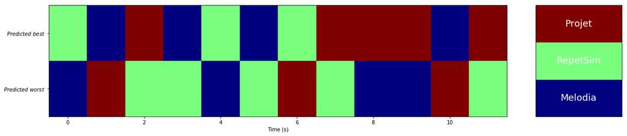

[interactive chart not shown]

```python
separated['fg']['Projet'] = separated['projet'][0]

import nussl
from audio_embed import utilities
import matplotlib.pyplot as plt
switcher = AlgorithmSwitcher(mix,
                             [separated['fg'][a.__name__] for a in approaches], [a.__name__ for a in approaches],
                            model = '/home/prem/research/nussl/nussl/separation/models/vocal_sdr_predictor.model')
bg_s, fg_s = switcher.run()
plt.figure(figsize=(20, 4))
switcher.plot(None)
plt.show()

utilities.multitrack([(bg_s, 'Switcher background'), (fg_s, 'Switcher foreground')])
```

Finally, above is the output using our system. The noise bursts are don't leak into the foreground as much as they do in the individual algorithms above.